### Documentation for the Diamond Price app

The purpose of this app is to demonstrate simple linear regression and prediction intervals.

It uses the little `diamond` data set (available in the library `UsingR`). This gives the weight (in carats) and price (in Singapore dollars) of four dozen diamonds.

### How to use the app:

To use the app, just enter a weight in carats and click the ‘submit’ button. The app should work for any positive value for carats, but the plot shown will work correctly for carats in the range of 0.1 to 0.35 carats.

When a weight is entered, the predicted price is computed, along with a 95% prediction interval (so that with probability 0.95, the interval will include the price of a diamond of that weight).

The app displays a plot showing the linear regression model, and also red lines indicating the predicted price and prediction interval. The graph shows prediction interval bands (note how the red lines fit this to indicate the prediction interval for the given number of carats).

### How the app works:

Here, we look under the hood to see how the calculations for this app are done in R. This shows the model that is being fit to the data, a simple linear regression predicting price as a function of weight in carats.

The predicted diamond price uses the standard `lm` function in R, along with its associated `predict` function. The core of the Shiny app code is similar to the following. (Note the code here is modified to remove its ‘reactivity’ from the version in the Shiny app.)

First we fit the model to the data.

```r
library(UsingR)
data(diamond)
str(diamond)
```

```
'data.frame':   48 obs. of  2 variables:
 $ carat: num  0.17 0.16 0.17 0.18 0.25 0.16 0.15 0.19 0.21 0.15 ...
 $ price: int  355 328 350 325 642 342 322 485 483 323 ...
```

```r
x <- diamond$carat; y <- diamond$price
fit <- lm(y ~ x)
```

Now we find the predicted value and prediction interval.

```r
input.carats <- 0.24; xseq <- seq(0.05,0.375,0.01)
pred.ci <- predict(fit, newdata = data.frame(x = input.carats),
                           interval="prediction")
# this is for the gray band in the plot
pred.bands <- predict(fit, newdata = data.frame(x = xseq),
                           interval="prediction")
# output predicted value and prediction interval
cat("predicted value:", pred.ci[1], "\n")
```

```
predicted value: 633.4201
```

```r
cat("prediction interval: ", pred.ci[2], ", ", pred.ci[3], "\n", sep="")
```

```
prediction interval: 568.3961, 698.444
```

Now we build the plot.

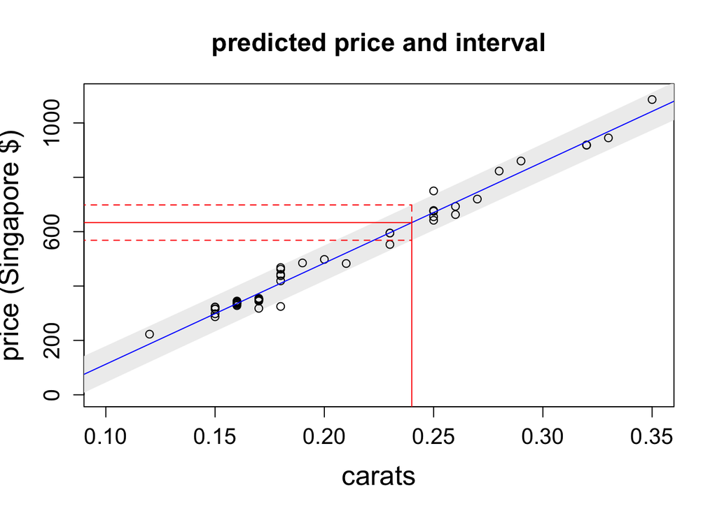

```r
# build plot
plot(x, y, xlab="carats", ylab="price (Singapore $)", type="n",
     main="predicted price and interval", cex.main=1.5,
     xlim=c(0.1,0.35),ylim=c(0,1100), cex.lab=1.6, cex.axis=1.3, cex=1.3)
# add prediction band
perimeter_x <- c(xseq, rev(xseq))
perimeter_y <- c(pred.bands[,2], rev(pred.bands[,3]))
polygon(perimeter_x, perimeter_y, col="#EEEEEE", border=NA)
# add diamond plot points and regression line
points(x, y)
abline(fit,col="blue")
# add red linels showing predicted value and CI on plot
lines(c(input.carats,input.carats), c(-100, pred.ci[1]), lty=1, lwd=1, col="red")
lines(c(input.carats,input.carats), c(pred.ci[1], pred.ci[3]), lty=2, col="red")
lines(c(0,input.carats), c(pred.ci[3], pred.ci[3]),
      col="red", lwd=1, lty=2)
lines(c(0,input.carats), c(pred.ci[2], pred.ci[2]),
      col="red", lwd=1, lty=2)
lines(c(0,input.carats), c(pred.ci[1], pred.ci[1]),
      col="red", lwd=1, lty=1)
```